# SQL and R

Nataliya Ferdinand

2024-09-08

# Introduction

#### **Setting a CRAN mirror before installing the package “DBI”**

When I am trying to install the DBI package in my RMarkdown file, R is attempting to connect to CRAN without specifying which mirror (server) to use. Thus, I need to set a CRAN mirror before installing the package “DBI”

```r
options(repos = c(CRAN = "https://cloud.r-project.org"))
```

##### **Installing packages**

I installed “DBI” package that provides an easy way to connect with SQL databases, allowing to obtain, modify, and analyze data in real-time. Also, I installed “RMySQL” package since I am using MySQL.

```r
install.packages("DBI")
install.packages("RMySQL")
```

#### **Establishing Database Connection**

I need to establish a connection to my SQL database (MySQL) before running queries.

```r
library(DBI)
movie_database<-dbConnect(RMySQL::MySQL(),
               dbname="movie",
               host ="localhost", #or my SQL server address
               port = 3306,
               user = "root",
               password="Matrix%607")

#check if connection is successful
dbListTables(movie_database)
```

```
## [1] "movies"       "users"        "users_movies"
```

```r
movies_table<-dbGetQuery(movie_database, "select * from movies")
movies_table
```

```
##   movieid           title release_year       director duration
## 1    mid1      The Matrix         1999 Lana Wachowski      120
## 2    mid2  The Terminator         1984  James Cameron      120
## 3    mid3   The Originals         2013     Julie Plec     3680
## 4    mid4 Game of Thrones         2011    Alan Taylor     2920
## 5    mid5        Hunnibal         2015      Adam Kane     1560
##                                                                                                                                                            description
## 1                                                           The Martix is an action, science fiction film about a computer hacker who discovers that his life is a lie
## 2                                                    The movie focuses on a post-apocalyptic war between a synthetic intelligence and a surviving resistance of humans
## 3                                                                     The family of power-hungry thousand-year-old vampires look to take back the city that they built
## 4 Game of Thrones is an HBO series that follows the story of several noble families fighting for control of the Iron Throne in the fictional Seven Kindoms of Westeros
## 5       In NBC hour-long drama, Will Graham is a professor and FBI criminal profiler who is drawn into a professional association with a man who is secretly a monster
##   language created_at
## 1  English 1999-05-11
## 2  English 1984-01-21
## 3  English 2013-10-03
## 4  English 2011-04-17
## 5  English 2015-08-29
```

#### **Checking all columns of all three tables: users, movies, and users_movies**

I created three tables and I want to see all the columns and the data in each column.

```r
users_table<-dbGetQuery(movie_database, "select * from users")
users_table
```

```
##   userid username                 email     password date_of_birth gender
## 1   uid1   Oksana oksanamovie@gmail.com LikeMovies55    1975-06-17 female
## 2   uid2     John    John7345@gmail.com    MTRdcf$88    1991-09-25   male
## 3   uid3    Susan      LSusan@gmail.com    Gir89tree    1979-08-02 female
## 4   uid4     Igor    Igor_pal@gmail.com CrTfkjg%0908    1971-02-24   male
## 5   uid5     Irma     Irma908@gmail.com SelUniNYC$12    1983-05-01 female
##   status created_at
## 1 active 2022-11-18
## 2 active 2021-12-11
## 3 active 2019-04-15
## 4 active 2023-03-21
## 5 active 2022-08-14
```

```r
users_movies_table<-dbGetQuery(movie_database, "select * from users_movies")
users_movies_table
```

```
##    userid movieid watch_date rating                           review
## 1    uid1    mid1 2023-10-18      4                      Great movie
## 2    uid1    mid2 2024-05-01      3          It is Ok, but old movie
## 3    uid1    mid3 2023-12-15      2             It is childish movie
## 4    uid1    mid4 2024-10-04      5            It is interesting one
## 5    uid1    mid5 2022-07-03      5         It is exciting and scary
## 6    uid2    mid1 2022-11-16      4                Interesting movie
## 7    uid2    mid2 2023-03-21      4                I like this movie
## 8    uid2    mid3 2023-12-15     NA                             <NA>
## 9    uid2    mid4 2022-12-07      5                It is interesting
## 10   uid2    mid5       <NA>     NA                             <NA>
## 11   uid3    mid1 2022-10-22     NA                             <NA>
## 12   uid3    mid2 2024-01-01      3 Not interesting as it was before
## 13   uid3    mid3 2023-10-14      4                     Entertaining
## 14   uid3    mid4       <NA>     NA                             <NA>
```

[output cut: 37 more lines]

#### **The SQL query to join the tables**

Since the columns of interest locates in different columns, I need to join them. The columns which I want to get are userid and username from “Users” table; movieid and title are from “movies” table; and rating column is from “users_movies” table.

```r
query1<-"select u.userid, u.username, t.movieid, t.title, r.rating
       from movies t JOIN users_movies r
       ON t.movieid=r.movieid
       JOIN users u ON u.userid=r.userid"
result1<-dbGetQuery(movie_database, query1)
result1
```

```
##    userid username movieid           title rating
## 1    uid5     Irma    mid1      The Matrix      4
## 2    uid4     Igor    mid1      The Matrix      4
## 3    uid3    Susan    mid1      The Matrix     NA
## 4    uid2     John    mid1      The Matrix      4
## 5    uid1   Oksana    mid1      The Matrix      4
## 6    uid5     Irma    mid2  The Terminator      2
## 7    uid4     Igor    mid2  The Terminator      3
## 8    uid3    Susan    mid2  The Terminator      3
## 9    uid2     John    mid2  The Terminator      4
## 10   uid1   Oksana    mid2  The Terminator      3
## 11   uid5     Irma    mid3   The Originals      4
## 12   uid4     Igor    mid3   The Originals     NA
## 13   uid3    Susan    mid3   The Originals      4
## 14   uid2     John    mid3   The Originals     NA
## 15   uid1   Oksana    mid3   The Originals      2
## 16   uid5     Irma    mid4 Game of Thrones      5
## 17   uid4     Igor    mid4 Game of Thrones      5
## 18   uid3    Susan    mid4 Game of Thrones     NA
## 19   uid2     John    mid4 Game of Thrones      5
## 20   uid1   Oksana    mid4 Game of Thrones      5
## 21   uid5     Irma    mid5        Hunnibal      5
## 22   uid4     Igor    mid5        Hunnibal      4
## 23   uid3    Susan    mid5        Hunnibal      4
## 24   uid2     John    mid5        Hunnibal     NA
## 25   uid1   Oksana    mid5        Hunnibal      5
```

#### **Installing “dplyr” package**

I need “dplyr” package for making data manipulation easier. For example, I filter only those observations (rows) that do not have missing data (NA).

```r
library(dplyr)
result_clean<-result1%>%filter(!is.na(rating))
result_clean
```

```
##    userid username movieid           title rating
## 1    uid5     Irma    mid1      The Matrix      4
## 2    uid4     Igor    mid1      The Matrix      4
## 3    uid2     John    mid1      The Matrix      4
## 4    uid1   Oksana    mid1      The Matrix      4
## 5    uid5     Irma    mid2  The Terminator      2
## 6    uid4     Igor    mid2  The Terminator      3
## 7    uid3    Susan    mid2  The Terminator      3
## 8    uid2     John    mid2  The Terminator      4
## 9    uid1   Oksana    mid2  The Terminator      3
## 10   uid5     Irma    mid3   The Originals      4
## 11   uid3    Susan    mid3   The Originals      4
## 12   uid1   Oksana    mid3   The Originals      2
## 13   uid5     Irma    mid4 Game of Thrones      5
## 14   uid4     Igor    mid4 Game of Thrones      5
## 15   uid2     John    mid4 Game of Thrones      5
## 16   uid1   Oksana    mid4 Game of Thrones      5
## 17   uid5     Irma    mid5        Hunnibal      5
## 18   uid4     Igor    mid5        Hunnibal      4
## 19   uid3    Susan    mid5        Hunnibal      4
## 20   uid1   Oksana    mid5        Hunnibal      5
```

#### **Calculation of average rating per movie**

In order to create a graph that will show an average rating for each movie, I used summarize(), mean() group_by() functions.

```r
# Calculate average rating per movie
avg_rating_per_movie <- result_clean %>%
  group_by(title) %>%
  summarise(avg_rating = mean(rating))
avg_rating_per_movie
```

```
## # A tibble: 5 × 2
##   title           avg_rating
##   <chr>                <dbl>
## 1 Game of Thrones       5
## 2 Hunnibal              4.5
## 3 The Matrix            4
## 4 The Originals         3.33
## 5 The Terminator        3
```

#### **Creation of a bar plot of average ratings**

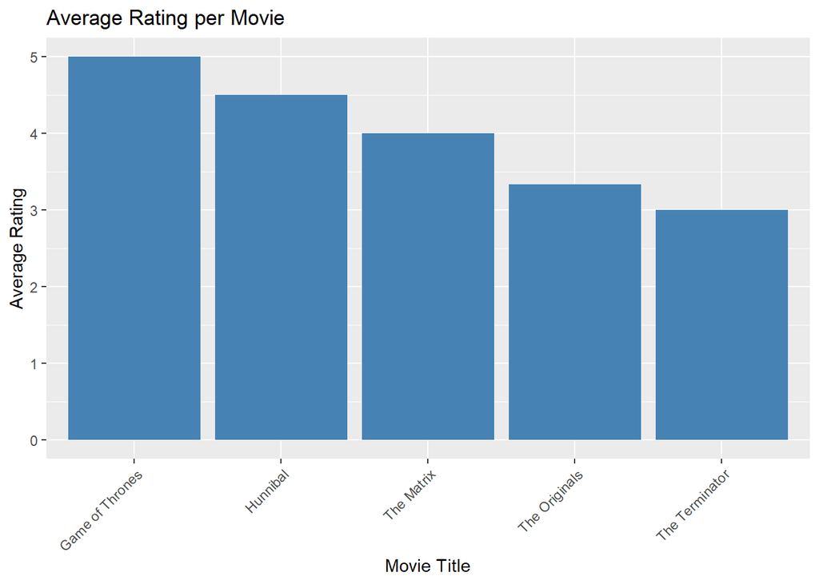

```r
# Create a bar plot of average ratings
library(ggplot2)
ggplot(avg_rating_per_movie, aes(x = title, y = avg_rating)) +
  geom_bar(stat = "identity", fill = "steelblue") +
  theme(axis.text.x = element_text(angle = 45, hjust = 1)) +
  labs(title = "Average Rating per Movie", x = "Movie Title", y = "Average Rating")
```

```r
dbDisconnect(movie_database)
```

```
## [1] TRUE
```

# Conclusion:

After analyzing the ratings from all five participants, the movie *Game of Thrones* emerged as the highest-rated, consistently receiving strong feedback. Based on the ratings provided, it secured the top spot with the highest average score, demonstrating its popularity and appeal among the group of respondents.